# Titanic_EDA

## 前期准备

```python
%matplotlib inline
%config InlineBackend.figure_format = 'retina'

import matplotlib.pyplot as plt
import matplotlib
import seaborn as sns

import numpy as np
import pandas as pd
```

```python
#在plt中使用中文
!gdown --id 1fsKERl26TNTFIY25PhReoCujxwJvfyHn
import matplotlib as mpl
zhfont = mpl.font_manager.FontProperties(fname='SimHei .ttf')
```

```
Downloading...
From: https://drive.google.com/uc?id=1fsKERl26TNTFIY25PhReoCujxwJvfyHn
To: /content/SimHei .ttf
100% 10.1M/10.1M [00:00<00:00, 46.6MB/s]
```

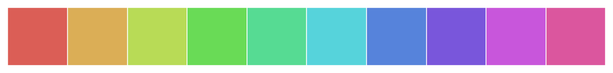

```python
# 设置主题
sns.set_style("darkgrid")
sns.palplot(sns.color_palette("hls", 10))
```

```python
trainset = pd.read_csv(r"/content/data.csv")
testset = pd.read_csv(r"/content/test.csv")
```

```python
# trainset.shape
trainset.head()
```

|  | PassengerId | Survived | Pclass | Name | Sex | Age | SibSp | Parch | Ticket | Fare | Cabin | Embarked |
| --- | --- | --- | --- | --- | --- | --- | --- | --- | --- | --- | --- | --- |
| 0 | 1 | 0 | 3 | Braund, Mr. Owen Harris | male | 22.0 | 1 | 0 | A/5 21171 | 7.2500 | NaN | S |
| 1 | 2 | 1 | 1 | Cumings, Mrs. John Bradley (Florence Briggs Th... | female | 38.0 | 1 | 0 | PC 17599 | 71.2833 | C85 | C |
| 2 | 3 | 1 | 3 | Heikkinen, Miss. Laina | female | 26.0 | 0 | 0 | STON/O2. 3101282 | 7.9250 | NaN | S |
| 3 | 4 | 1 | 1 | Futrelle, Mrs. Jacques Heath (Lily May Peel) | female | 35.0 | 1 | 0 | 113803 | 53.1000 | C123 | S |
| 4 | 5 | 0 | 3 | Allen, Mr. William Henry | male | 35.0 | 0 | 0 | 373450 | 8.0500 | NaN | S |

survived表示是否生还，0代表死，1代表生。

pclass代表票的等级，分别是1,2,3等。

sibsp为兄弟姐妹以及配偶的人数。

parch为父母或子女/直系亲属的数量。

ticket为票号，fare是票价，cabin是舱位，

embarked是登船地点， S，C，Q分别代表三个城市。C = Cherbourg, Q = Queenstown, S = Southampton。

```python
trainset.shape
# trainset.info
# trainset.describe
```

```
(891, 12)
```

## 数据清洗

### 处理缺失值

```python
trainset.isnull().sum()
```

```
PassengerId      0
Survived         0
Pclass           0
Name             0
Sex              0
Age            177
SibSp            0
Parch            0
Ticket           0
Fare             0
Cabin          687
Embarked         2
dtype: int64
```

```python
trainset.Age.fillna(-30, inplace=True)
```

```python
trainset.isnull().sum()
```

```
PassengerId      0
Survived         0
Pclass           0
Name             0
Sex              0
Age              0
SibSp            0
Parch            0
Ticket           0
Fare             0
Cabin          687
Embarked         2
dtype: int64
```

## 数据分析

面对数据前，总有思考我们想探究的问题，通过可视化，想寻得怎样的答案呢？

我的关注点在舱位（身份地位）、性别、年龄等影响因素上。

### 舱位对生还与否的影响

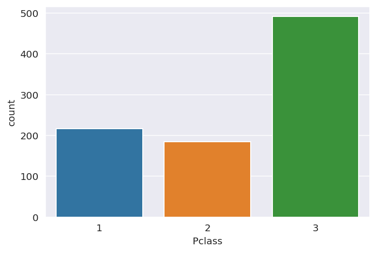

```python
sns.countplot(x="Pclass", data=trainset)
```

可以看出三等舱乘客人数最多，其次是头等舱，乘客人数最少的是次等舱

各个船舱乘客生死情况

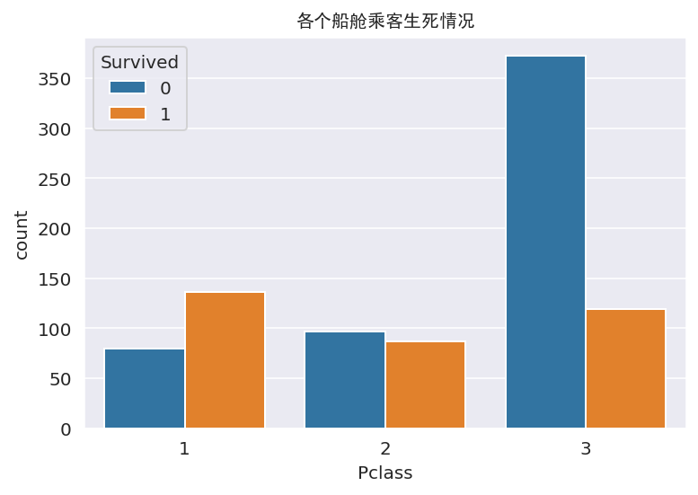

```python
# 分层分组直方图
sns.countplot(data=trainset, x="Pclass", hue="Survived")
plt.title(u"各个船舱乘客生死情况", fontproperties=zhfont)
plt.show()
```

由上图可以看出三等舱死亡人数最多，死亡人数比重较大；而头等舱的生还人数占比要比死亡人数占比大，生还人数也最多；对于次等舱，死亡人数和生还人数比约为1:1。

### 性别Sex对生还与否的影响

```python
# 汇总统计
trainset.groupby(['Sex','Survived'])['Survived'].count()
```

```
Sex     Survived
female  0            81
        1           233
male    0           468
        1           109
Name: Survived, dtype: int64
```

```python
# 各舱男女生还率统计
df_sex = trainset[['Pclass', 'Sex', 'Survived']].groupby(['Pclass', 'Sex']).mean()
df_sex
```

| Pclass | Sex | Survived |
| --- | --- | --- |
| 1 | female | 0.968085 |
|  | male | 0.368852 |
| 2 | female | 0.921053 |
|  | male | 0.157407 |
| 3 | female | 0.500000 |
|  | male | 0.135447 |

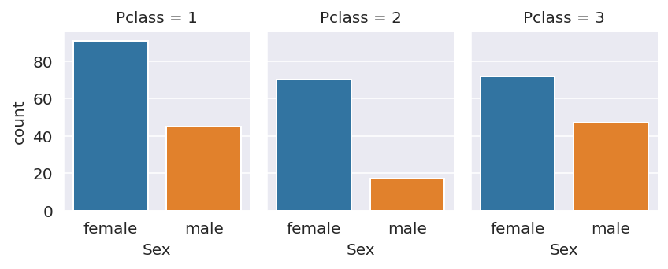

```python
# # 不同的deck（因子）绘制不同的alive（数值），col为分子图绘制，col_wrap每行画3个子图
g = sns.catplot(x="Sex", col="Pclass", col_wrap=3,
                    data=trainset[trainset['Survived']==1],
                    kind="count", height=2.5, aspect=.8)
```

各仓都是女性存活率更高，有悖于男性生存能力更强的常识，应该是Lady First的绅士精神发挥了作用。

Lady First确实跨越了社会等级界限，三等舱的女性的生还率都高于头等舱的男性生还率。

不过，无法忽视的是，不同舱位的生还率还是有一定区别的。

### 年龄Age对生还与否的影响

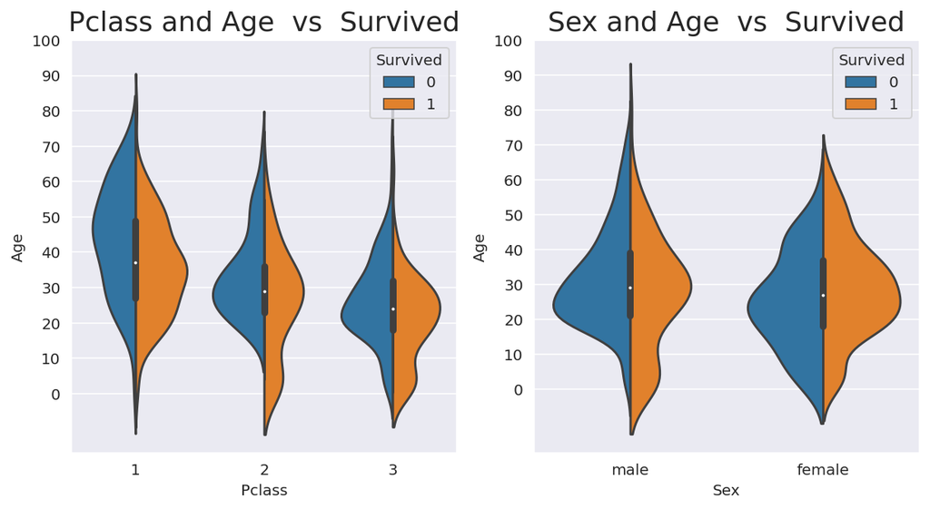

```python
# 绘图分析不同阶层和不同性别下的年龄分布情况以及与生还的关系

fig, ax = plt.subplots(1, 2, figsize=(10,5))
sns.violinplot('Pclass','Age', hue='Survived', data=trainset, split=True, ax=ax[0])
ax[0].set_title('Pclass and Age  vs  Survived',size=18)
ax[0].set_yticks(range(0, 110, 10))

sns.violinplot("Sex", "Age", hue="Survived", data=trainset, split=True, ax=ax[1])
ax[1].set_title('Sex and Age  vs  Survived',size=18)
ax[1].set_yticks(range(0, 110, 10))
plt.show()
```

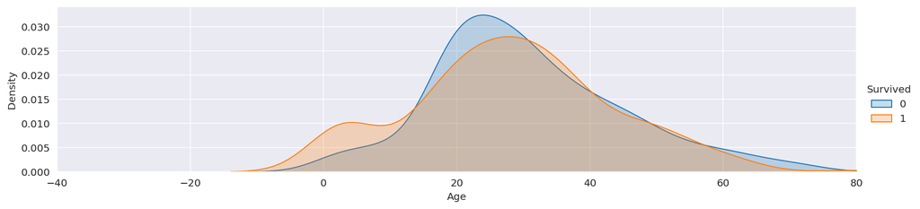

```python
page = sns.FacetGrid(trainset, hue="Survived",aspect=4)
page.map(sns.kdeplot,'Age',shade= True)
page.set(xlim=(-40, trainset['Age'].max()))
page.add_legend()
plt.show()
```

从上图看来，未成年人生还可能性更大

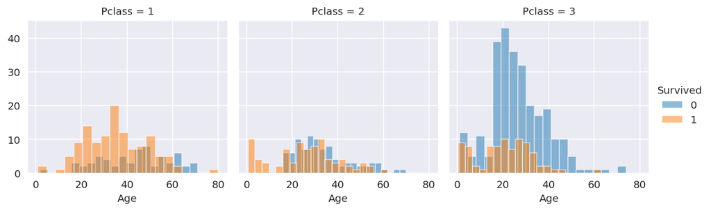

```python
grid = sns.FacetGrid(trainset, col='Pclass', hue='Survived')
grid.map(plt.hist, 'Age', alpha=.5, bins=20)
grid.add_legend()
```

### 小节

```python
trainset
```

```python
titanic = trainset.copy()
titanic['Sex'] = titanic['Sex'].apply(lambda x : 1 if x == 'male' else x)
titanic['Sex'] = titanic['Sex'].apply(lambda x : 0 if x == 'female' else x)
titanic
```

[output not shown]

891 rows × 12 columns

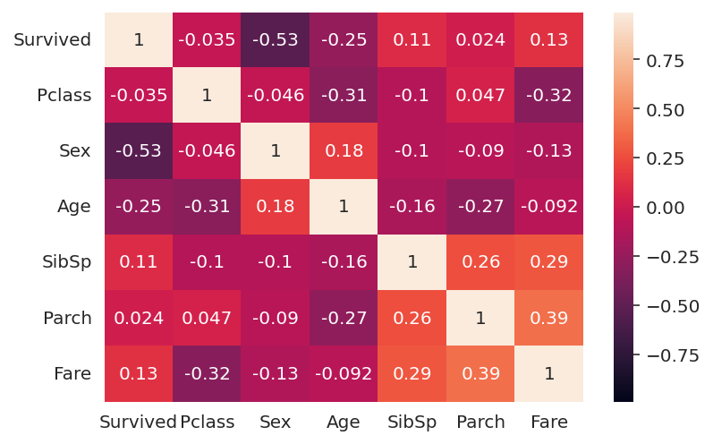

```python
traincorr = titanic.dropna().drop('PassengerId',axis=1).corr()
sns.heatmap(traincorr, vmax=0.99, vmin=-0.99, annot=True)
plt.show()
```

parch和age有些负相关，可能因为小孩子age小、有父母陪同所以parch大，但parch和survived的关系不大。

Fare和Pclass是负相关的，因为fare越高、class越小（偏向头等舱）；而之前的结果也说明了头等舱的存活率更高，即fare越高生还可能性越高。

## 开始预测（暂缓）

```python
svvd = trainset['Survived']
```

```python
dead_rate = len(svvd[svvd == 0]) / len(svvd)
dead_rate
```

```
0.6161616161616161
```

死亡率有百分之六十多，也就是说，如果直接全部预测死亡的话，还会有60%左右的准确率。

这个数值应当作为benchmark，因为不需要对特征进行任何分析，直接考虑需要预测结果的分布都能达到这样的准确率。

TP——True Positive 真阳性：预测为正，实际也为正

FP——False Positive 假阳性：预测为正，实际为负

FN——False Negative 假阴性：预测与负、实际为正

TN——True Negative 真阴性：预测为负、实际也为负

精确率(查准率)是针对我们预测结果而言的，它表示的是预测为正的样本中有多少是真正的正样本。那么预测为正就有两种可能了，一种就是把正类预测为正类(TP)，另一种就是把负类预测为正类(FP)，也就是

$$P = TP/(TP+FP)$$

而召回率（查全率）是针对我们原来的样本而言的，它表示的是样本中的正例有多少被预测正确了。那也有两种可能，一种是把原来的正类预测成正类(TP)，另一种就是把原来的正类预测为负类(FN)。其实就是分母不同，一个分母是预测为正的样本数，另一个是原来样本中所有的正样本数

$$R = TP/(TP+FN)$$

其实就是分母不同，一个分母是预测为正的样本数，另一个是原来样本中所有的正样本数。

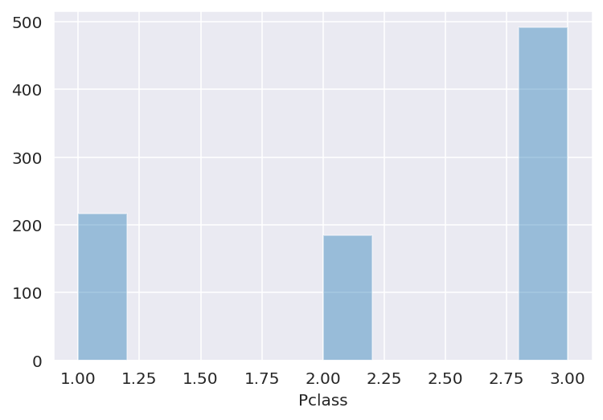

```python
sns.distplot(trainset.Pclass,kde=False)
plt.show()
```

可以看出三等舱人数最多，其次是头等舱，人数最少的是次等舱

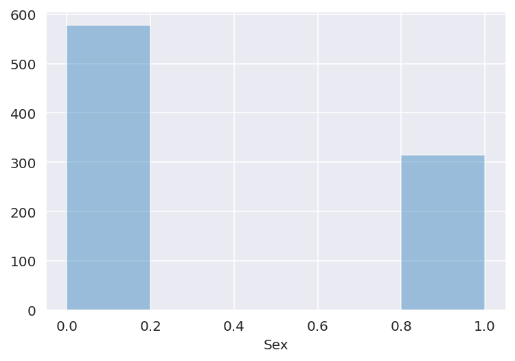

```python
# loc 定位到sex==‘male’的行，后面表示修改‘sex’column的值
trainset.loc[trainset.Sex == 'male','Sex'] = 0
trainset.loc[trainset.Sex == 'female','Sex'] = 1
sns.distplot(trainset.Sex,kde=False)
plt.show()
```

## 创建pdf

```python
!apt update
!apt install texlive-xetex texlive-fonts-recommended texlive-generic-recommended

import re, pathlib, shutil

# Get a list of all your Notebooks
notebooks = [x for x in pathlib.Path("/content").iterdir() if
             re.search(r"\.ipynb", x.name, flags = re.I)]

for i, n in enumerate(notebooks):
    print(f"\nProcessing  [{i+1:{len(str(len(notebooks)))}d}/{len(notebooks)}]  {n.name}\n")

    # Optionally copy your notebooks from gdrive to your vm
    shutil.copy(n, n.name)
    n = pathlib.Path(n.name)

    !jupyter nbconvert "{n.as_posix()}" --to pdf --output "{n.stem.replace(" ", "_")}"
```

[output not shown]

[output cut: 272 more lines]

[output not shown]

```python
!apt-get install texlive texlive-xetex texlive-latex-extra pandoc
!pip install pypandoc
```

[output not shown]

```python
from google.colab import drive
drive.mount('/content/Titanic_EDA.ipynb')
```

```python
!cp drive/MyDrive/ColabNotebooks/Titanic_EDA.ipynb ./
```

[output not shown]